# Ensemble_Methods_for_Outlier_Detection_Version_2.0

Jian Song, Nathan P. Manes

5/5/2022

## 1. Set the Statistical Parameters and Prepare and Visualize the Input Data

The four statistical cutoff values are set below. Your input file is loaded in here. The data are filtered by removing any row with “NaN” (missing values). Density plots are used to visualize the distribution of gene/protein expression values within each sample and across the samples. The normality of the dataset is visualized and tested. Note that it is unclear how accurately outliers will be detected if the input dataset is significantly different from a normal distribution.

```r
# Set the Cophenetic Correlation Coefficient (CCC) cutoff (higher is more stringent).
# The CCC is a measure of how faithfully a dendrogram preserves the pairwise distances
# between the original unmodeled data points.
CCC_min <- 0.8

# Set the Silhouette Coefficient (SC) cutoff (lower is more stringent).
# The SC is a measure of how similar an object is to its own cluster (cohesion) compared to other clusters (separation).
SC_max <- 0.25

# Set the Robust PCA algorithm (robpca) cutoff (higher is more stringent).
# For normally distributed data, this value is the estimated fraction of the samples that are not falsely classified as outliers.
robpca_prob <- 0.975

# Set the Robust PCA algorithm (PcaGrid) cutoff (higher is more stringent)
# For normally distributed data, this value is the estimated fraction of the samples that are not falsely classified as outliers.
PcaGrid_prob <- 0.975


# To analyze your table of data, paste it in a new Excel file named "Gene_Expression_Table.xlsx".
# Rows = genes/proteins.  Columns = samples.  Values = expression values.
# The first row is for the column headers (sample identifiers).
# Don't have gene/protein identifiers in the first column; use all columns for abundance values.
# Place this file in the same directory as this R script.
# Optional: if present, remove any extra header rows using e.g. "skip=19" - which will remove the 19 header rows
input_data <- readxl::read_xlsx("./Gene_Expression_Table.xlsx", skip = 0, col_names = TRUE, col_types=NULL)
input_data <- data.frame(input_data)
rownames(input_data) <- input_data$Leading.Protein.ID
input_data$Leading.Protein.ID <- NULL # Remove the gene/protein ID column if present
input_data <- as.data.frame(sapply(input_data, as.numeric))

# Display the first six rows of the input data
head(input_data)
```

```
##            i4          i5          i7         i10         i11           i20
## 1 -0.50130005 -0.08145817  0.18926625  0.07331069  0.44084706 -0.1140053406
## 2  0.25879225  0.05582049  0.04274337 -0.22423394  0.02430090  0.3442883783
## 3  0.61489408  0.02122731 -0.51557822 -0.59817950 -0.08343760  0.5420806096
## 4 -0.05206937 -0.20007908  0.42867041 -0.23847456  0.41293056  0.0451141953
## 5  0.14676844 -0.44802526 -0.11852191  0.32253208  0.07276012  0.4283776845
## 6 -0.47966100 -0.14848675  0.11707971  0.38959273  0.12290331 -0.0003212195
##           i22         i24         i25         i36        i37        i39
## 1  0.15638845  0.06291271  0.17481684  0.11392403 -0.2928460 -0.1000304
## 2 -0.01151561  0.07018217 -0.26305803  0.01665247  0.3206011  0.2789249
## 3 -0.26378718 -0.71359136 -0.25702136  0.06382914 -0.3806405 -0.9054200
## 4 -0.08249761  0.15740306  0.46496917  0.41474509  0.2840817  0.1702511
## 5 -0.44495142  0.06849507 -0.05321401 -0.14111744 -0.3509007  0.3475898
## 6  0.22087711 -0.48793254  0.10744851  0.25737015 -0.2358608  0.3155016
##           i41         i42         i43         i52         i57        i58
```

[output cut: 1721 more lines]

```r
# Display the dimension of the input table
# Number of rows (genes/proteins) and the number of columns (samples)
dim(input_data)
```

```
## [1]  731 1490
```

```r
# Remove any row (genes/proteins) with one or more invalid values ("NaN")
input_data_nna <- input_data[complete.cases(input_data), ]
# Display how many rows remain after removing the rows with NaN's
input_data_nna_rows <- dim(input_data_nna)[1]
input_data_col <- dim(input_data_nna)[2]
dim(input_data_nna)
```

```
## [1]  731 1490
```

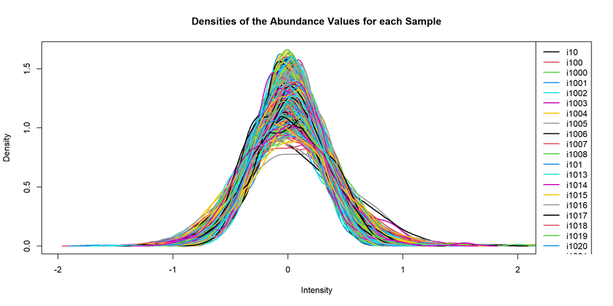

```r
# Plot the density of expression values for all of the samples on the same plot.
# If the samples are very diverse, a global normalization might be helpful.
# Note that this is not a visualization of how close the quantification is to a normal distribution.
plotDensities(input_data_nna, log = FALSE, main="Densities of the Abundance Values for each Sample", legend = "topright")
```

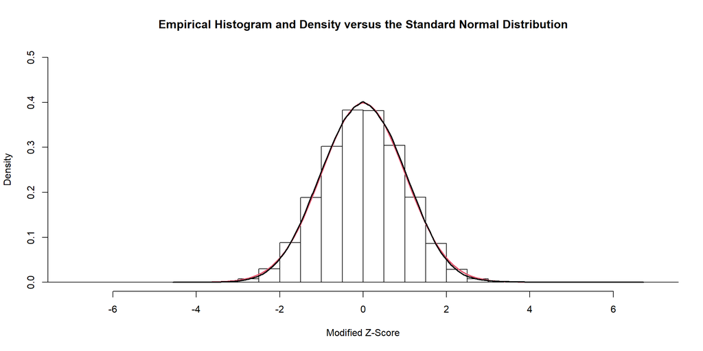

```r
# We cannot label each line in the plot above, but we can plot a subset of
# the samples to be able to differentiate the lines.
# For example, to plot the distributions of 'Sample_01', 'Sample_02', and 'Sample_03', use
# plotDensities(input_data_nna[c('Sample_01', 'Sample_02', 'Sample_03')], log = FALSE, main="Densities of the Abundance Values for Selected Samples", legend = "topright")
#
# The expression values should have a normal distribution.  To check this,
# the data are scaled by calculating the Modified Z-score (Iglewicz and Hoaglin 1993)
# within each row across the samples.

input_data_nna_median <- vector("numeric", input_data_nna_rows)
for (i in 1:input_data_nna_rows) {
input_data_nna_median[i] <- median(unlist(input_data_nna[i,]))
}

input_data_nna_MAD <- vector("numeric", input_data_nna_rows)
for (i in 1:input_data_nna_rows) {
input_data_nna_MAD[i] <- mad(unlist(input_data_nna[i,]), center = input_data_nna_median[i], constant = 1, na.rm = TRUE, low = FALSE, high = FALSE)
}

input_data_nna_ModZ <- matrix(nrow = input_data_nna_rows, ncol = input_data_col)
for (i in 1:input_data_nna_rows) {
 for (j in 1:input_data_col) {
   input_data_nna_ModZ[i,j] <- 0.6745 * (input_data_nna[i,j] - input_data_nna_median[i]) / input_data_nna_MAD[i]
 }
}

# To use regular Z-scores, enable the line below.
# This can be used to avoid artifacts from using the Modified Z-score.
# input_data_nna_ModZ <- t(scale(t(input_data_nna), center = TRUE, scale = TRUE))
#
# Plot the histogram and density of the Modified Z-scores versus a standard normal distribution (mean=0, SD=1)

input_data_nna_density <- density(as.vector(input_data_nna_ModZ), bw = "nrd0", adjust = 1, kernel = "gaussian", weights = NULL, window = kernel, give.Rkern = FALSE, n = 512, cut = 3, na.rm = TRUE)

density_x <- input_data_nna_density$x
density_y <- input_data_nna_density$y

hist_range <- seq(from = min(as.vector(input_data_nna_ModZ)), to = max(as.vector(input_data_nna_ModZ)), length.out = 101)

hist_range_normal <- dnorm(hist_range, mean = 0, sd = 1, log = FALSE)

hist(as.vector(input_data_nna_ModZ), breaks = seq(from = -99999, to = 99999, by = 0.5), freq = FALSE, include.lowest = FALSE, right = TRUE, density = NULL, angle = 45, col = NULL, border = NULL, main = "Empirical Histogram and Density versus the Standard Normal Distribution", xlim = c(-7, 7), ylim = c(0, 0.1 + max(max(hist_range_normal), max(density_y))), xlab = "Modified Z-Score", ylab = "Density", axes = TRUE, plot = TRUE, labels = FALSE, nclass = NULL, warn.unused = TRUE)

lines(hist_range, hist_range_normal, col = 2, lwd = 2)

lines(input_data_nna_density, col = 1, lwd = 2)
```

```r
# Calculate the coefficient of determination (R-squared) of the dataset to a standard normal distribution (mean=0, SD=1).
# Note that R-squared can sometimes be misleading (Spiess and Neumeyer 2010).
density_y_model <- dnorm(density_x, mean = 0, sd = 1, log = FALSE)
density_y_mean <- mean(density_y)
R_sq <- 1 - ( sum((density_y - density_y_model)^2) / sum((density_y - density_y_mean)^2) )
R_sq
```

```
## [1] 0.9995987
```

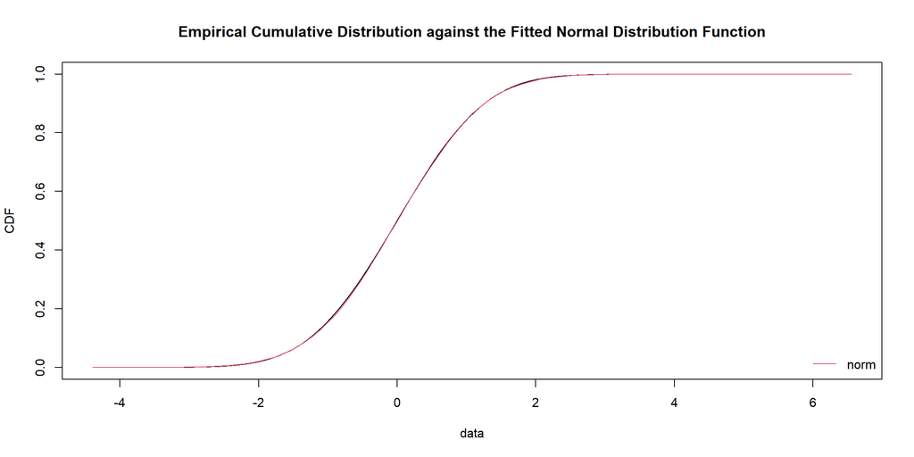

```r
# Fit the dataset to a normal distribution
fit_norm <- fitdist(as.vector(input_data_nna_ModZ), "norm", method = "mle", start=NULL, fix.arg=NULL, discrete = FALSE, keepdata = TRUE)

# Enable to make small versions of the four plots below
# plot(fit_norm)
#
# Enable to plot the Empirical Density against the Fitted Normal Distribution Function
# denscomp(fit_norm, probability = TRUE, main = "Empirical Density against the Fitted Normal Distribution Function", addlegend = TRUE, xlegend = "topright", ylegend = NULL, demp = TRUE, dempcol = "black", plotstyle = "graphics", fitnbpts = 101)
#
# Plot the Empirical Cumulative Distribution against the Fitted Normal Distribution Function
cdfcomp(fit_norm, xlogscale = FALSE, ylogscale = FALSE, main = "Empirical Cumulative Distribution against the Fitted Normal Distribution Function", datapch = 1, addlegend = TRUE, xlegend = "bottomright", ylegend = NULL, horizontals = TRUE, verticals = FALSE, do.points = TRUE, use.ppoints = TRUE, a.ppoints = 0.5, name.points = NULL, lines01 = FALSE, add = FALSE, plotstyle = "graphics", fitnbpts = 101)
```

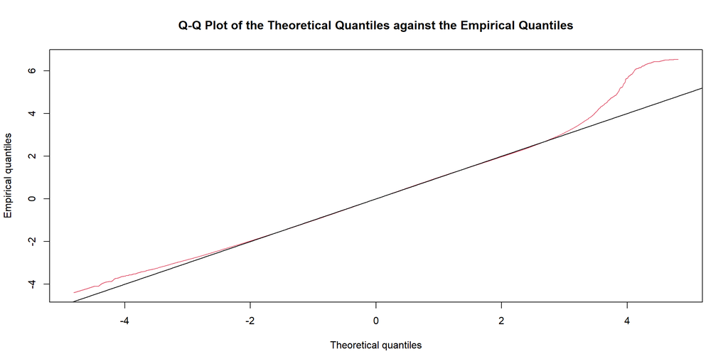

```r
# Q-Q Plot of the Theoretical Quantiles against the Empirical Quantiles
qqcomp(fit_norm, xlogscale = FALSE, ylogscale = FALSE, main = "Q-Q Plot of the Theoretical Quantiles against the Empirical Quantiles", addlegend = FALSE, xlegend = "bottomright", ylegend = NULL, use.ppoints = TRUE, a.ppoints = 0.5, line01 = TRUE, line01col = "black", line01lty = 1, ynoise = TRUE, plotstyle = "graphics")
```

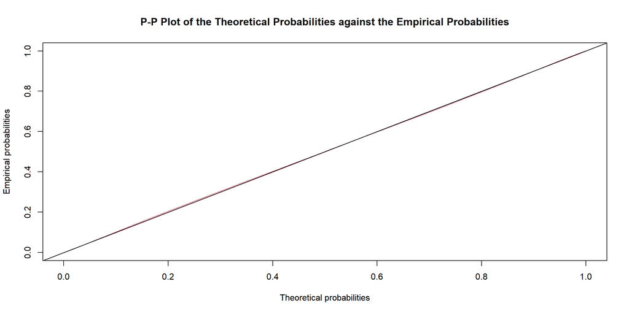

```r
# P-P Plot of the Theoretical Probabilities against the Empirical Probabilities
ppcomp(fit_norm, xlogscale = FALSE, ylogscale = FALSE, main = "P-P Plot of the Theoretical Probabilities against the Empirical Probabilities", addlegend = FALSE, xlegend = "bottomright", ylegend = NULL, use.ppoints = TRUE, a.ppoints = 0.5, line01 = TRUE, line01col = "black", line01lty = 1, ynoise = TRUE, plotstyle = "graphics")
```

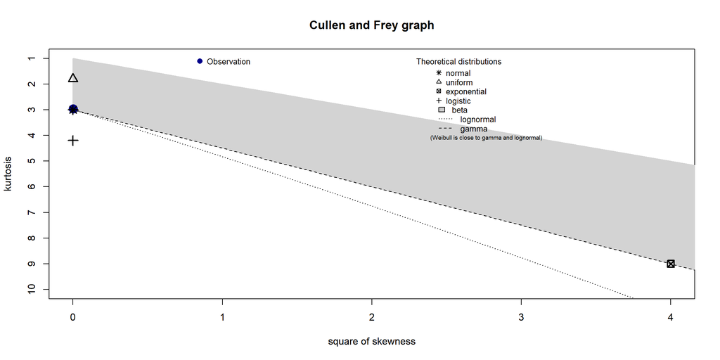

```
## summary statistics
## ------
## min:  -4.394315   max:  6.557723
## median:  2.701612e-18
## mean:  0.0007675185
## estimated sd:  0.980599
## estimated skewness:  0.03464138
## estimated kurtosis:  2.97006
```

```r
# Plot the Cullen and Frey graph (skewness-kurtosis plot)
descdist(as.vector(input_data_nna_ModZ), discrete = FALSE)
```

```r
# Perform a Shapiro-Wilk normality test (max input values = 5000)
SW_input <- as.vector(input_data_nna_ModZ)
if (length(SW_input) > 5000) {
SW_input <- sample(SW_input, 5000, replace = FALSE, prob = NULL)
}
SW_output <- shapiro.test(SW_input)
SW_output$p.value
```

```
## [1] 0.0001979201
```

```r
# Perform a Kolmogorov-Smirnov test to compare the dataset to a normal distribution
KS_output <- ks.test(as.vector(input_data_nna_ModZ), "pnorm", alternative = "two.sided")
KS_output$p.value
```

```
## [1] 0
```

## 2. Hierachical Clustering for the Cophenetic Correlation Coefficient

Hierarchical clustering analyses (HCAs) are performed, and the choice of the distance metric and linkage are determined using the Cophenetic Correlation Coefficient (CCC) (Selicato et al 2021). Three distance metrics and five linkages are used (15 HCA’s total). None of the three distance metrics are nonparametric so that the clustering is highly quantitative. The HCA that results in the largest CCC will be used for the downstream analyses. If this CCC < 0.8 (default value; CCC_min can be altered above), then the dendrogram is not a good representation of the relationships between the objects, and outliers can not be confidently detected (Selicato et al 2021). If CCC >= 0.8, the clustering was significant, and outliers can be detected if any exist.

```r
# Transpose the data so the sample will become the rows and genes/proteins will become the columns
input_data_nna_t <- t(input_data_nna)
rownames(input_data_nna_t)
```

```
##    [1] "i4"    "i5"    "i7"    "i10"   "i11"   "i20"   "i22"   "i24"   "i25"
##   [10] "i36"   "i37"   "i39"   "i41"   "i42"   "i43"   "i52"   "i57"   "i58"
##   [19] "i59"   "i68"   "i70"   "i72"   "i73"   "i74"   "i75"   "i85"   "i86"
##   [28] "i87"   "i88"   "i89"   "i90"   "i100"  "i101"  "i103"  "i104"  "i105"
##   [37] "i106"  "i116"  "i120"  "i121"  "i122"  "i123"  "i132"  "i134"  "i136"
##   [46] "i137"  "i138"  "i139"  "i149"  "i150"  "i151"  "i152"  "i154"  "i155"
##   [55] "i156"  "i157"  "i158"  "i159"  "i160"  "i164"  "i165"  "i168"  "i169"
##   [64] "i170"  "i171"  "i181"  "i182"  "i183"  "i184"  "i185"  "i186"  "i187"
##   [73] "i188"  "i190"  "i191"  "i192"  "i197"  "i198"  "i199"  "i200"  "i201"
##   [82] "i202"  "i203"  "i204"  "i205"  "i206"  "i207"  "i213"  "i214"  "i215"
##   [91] "i217"  "i218"  "i219"  "i220"  "i221"  "i222"  "i223"  "i224"  "i230"
##  [100] "i231"  "i232"  "i233"  "i234"  "i235"  "i236"  "i237"  "i238"  "i239"
##  [109] "i245"  "i246"  "i247"  "i248"  "i250"  "i251"  "i252"  "i253"  "i254"
##  [118] "i255"  "i261"  "i263"  "i265"  "i266"  "i267"  "i268"  "i269"  "i270"
##  [127] "i271"  "i272"  "i279"  "i280"  "i281"  "i282"  "i283"  "i284"  "i285"
```

[output cut: 151 more lines]

```r
# Calculate distances: Euclidean, Manhattan, Pearson correlation coefficient
d_e <- dist(input_data_nna_t, method = "euclidean")
d_m <- dist(input_data_nna_t, method = "manhattan")
c_2 = cor(input_data_nna, method="pearson")
d_p <- as.dist(1 - c_2)

# Linkages: "average" (= UPGMA), "ward.D2", "complete", "single", "centroid" (= UPGMC)
# Hierarchical clustering using Euclidean distance
hc_e_a <- hclust(d_e, method = "average" )
hc_e_w <- hclust(d_e, method = "ward.D2" )
hc_e_co <- hclust(d_e, method = "complete" )
hc_e_s <- hclust(d_e, method = "single" )
hc_e_ce <- hclust(d_e, method = "centroid" )
# Hierarchical clustering using Manhattan distance
hc_m_a <- hclust(d_m, method = "average" )
hc_m_w <- hclust(d_m, method = "ward.D2" )
hc_m_co <- hclust(d_m, method = "complete" )
hc_m_s <- hclust(d_m, method = "single" )
hc_m_ce <- hclust(d_m, method = "centroid" )
# Hierarchical clustering using Pearson correlation coefficient
hc_p_a <- hclust(d_p, method = "average" )
hc_p_w <- hclust(d_p, method = "ward.D2" )
hc_p_co <- hclust(d_p, method = "complete" )
hc_p_s <- hclust(d_p, method = "single" )
hc_p_ce <- hclust(d_p, method = "centroid" )

# The Cophenetic Correlation Coefficient (CCC) is a measure of how faithfully a dendrogram preserves the pairwise distances between the original unmodeled data points.
res.coph_e_a <- cophenetic(hc_e_a)
res.coph_e_w <- cophenetic(hc_e_w)
res.coph_e_co <- cophenetic(hc_e_co)
res.coph_e_s <- cophenetic(hc_e_s)
res.coph_e_ce <- cophenetic(hc_e_ce)

res.coph_m_a <- cophenetic(hc_m_a)
res.coph_m_w <- cophenetic(hc_m_w)
res.coph_m_co <- cophenetic(hc_m_co)
res.coph_m_s <- cophenetic(hc_m_s)
res.coph_m_ce <- cophenetic(hc_m_ce)

res.coph_p_a <- cophenetic(hc_p_a)
res.coph_p_w <- cophenetic(hc_p_w)
res.coph_p_co <- cophenetic(hc_p_co)
res.coph_p_s <- cophenetic(hc_p_s)
res.coph_p_ce <- cophenetic(hc_p_ce)

# Correlations between the distance matrix and the Cophenetic Correlations
# are compared for 'euclidean', 'manhattan', and 'pearson' distances to see which
# one is the best.  The higher the correlation, the better the HCA.
# Create a dataframe to store the CCC values from each distance and linkage combination
distance = c("euclidean", "euclidean", "euclidean", "euclidean", "euclidean",
             'manhattan', 'manhattan', 'manhattan', 'manhattan', 'manhattan',
             'pearson', 'pearson', 'pearson', 'pearson', 'pearson')
linkage = c('average', 'ward.D2', 'complete', 'single', 'centroid',
            'average', 'ward.D2', 'complete', 'single', 'centroid',
            'average', 'ward.D2', 'complete', 'single', 'centroid')
distance_matrix = c('e_a', 'e_w', 'e_co', 'e_s', 'e_ce',
                    'm_a', 'm_w', 'm_co', 'm_s', 'm_ce',
                    'p_a', 'p_w', 'p_co', 'p_s', 'p_ce')
CCC = c(
  cor(d_e, res.coph_e_a),
  cor(d_e, res.coph_e_w),
  cor(d_e, res.coph_e_co),
  cor(d_e, res.coph_e_s),
  cor(d_e, res.coph_e_ce),

  cor(d_m, res.coph_m_a),
  cor(d_m, res.coph_m_w),
  cor(d_m, res.coph_m_co),
  cor(d_m, res.coph_m_s),
  cor(d_m, res.coph_m_ce),

  cor(d_p, res.coph_p_a),
  cor(d_p, res.coph_p_w),
  cor(d_p, res.coph_p_co),
  cor(d_p, res.coph_p_s),
  cor(d_p, res.coph_p_ce))

CCC_df = data.frame(distance, linkage, distance_matrix, CCC)
CCC_df_ranked = CCC_df[order(-CCC_df$CCC),]

# Display the CCC for each HCA
CCC_df_ranked
```

```
##     distance  linkage distance_matrix        CCC
## 5  euclidean centroid            e_ce 0.69791080
## 10 manhattan centroid            m_ce 0.69428249
## 11   pearson  average             p_a 0.67919606
## 6  manhattan  average             m_a 0.57310374
## 12   pearson  ward.D2             p_w 0.57212758
## 1  euclidean  average             e_a 0.56756518
## 13   pearson complete            p_co 0.53491009
## 4  euclidean   single             e_s 0.48145396
## 9  manhattan   single             m_s 0.47116380
## 8  manhattan complete            m_co 0.42337066
## 3  euclidean complete            e_co 0.36492492
## 7  manhattan  ward.D2             m_w 0.35564175
## 2  euclidean  ward.D2             e_w 0.35378444
## 15   pearson centroid            p_ce 0.12547236
## 14   pearson   single             p_s 0.09289254
```

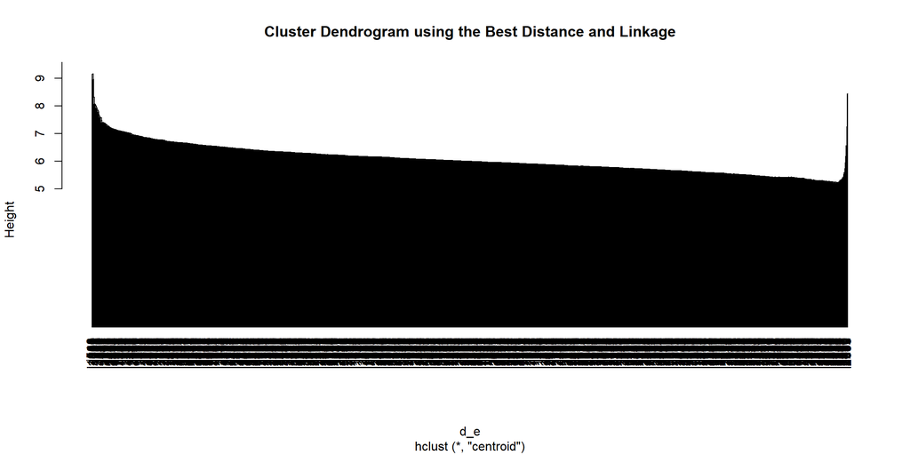

```r
# Find the best distance-linkage combination
CCC_df_ranked_top = CCC_df_ranked[1,]

# Get the hierarchical clustering object generated using the best distance-linkage
hc = get(paste0('hc_', CCC_df_ranked_top$distance_matrix))

# Display the dendrogram generated using the best distance-linkage
plot(hc, hang=-1, main='Cluster Dendrogram using the Best Distance and Linkage')
```

## 3. Hierachical Clustering for the Silhouette Coefficients

The Silhouette coefficient (SC) is calculated for each sample. A sample with SC < 0.25 (default value; SC_max can be altered above) is a potential outlier because it clustered poorly with the other samples; a sample with SC >= 0.25 is not a potential outlier (Selicato et al 2021).

```r
# Calculate the maximum possible number of clusters
# Note that eclust() -> hcut() might crash if this value is > 20
# Note that eclust() -> hcut() might crash if this value is > (input_data_col - 1)
MaxPosNumClusters <- min(c(20 , (input_data_col - 1) ))
MaxPosNumClusters
```

```
## [1] 20
```

```r
# eclust() - Visual enhancement of clustering analysis for enhancing the
# workflow of clustering analyses and ggplot2-based data visualization
hc.res_a <- eclust(input_data_nna_t, FUNcluster = "hclust", k = NULL, k.max = MaxPosNumClusters, stand = FALSE, graph = FALSE, hc_metric = CCC_df_ranked_top$distance, hc_method = CCC_df_ranked_top$linkage, nboot=100, seed=78)

# Display the estimated optimal number of clusters from eclust() gap statistics
nbclust_GapStat <- hc.res_a$nbclust
nbclust_GapStat
```

```
## [1] 19
```

```r
# If the estimated optimal number of clusters = 1, then the eclust() gap statistic
# method failed to identify an optimal number of clusters.
# Use the silhouette method (max of mean of SC values) (Charrad et al 2014).
if (nbclust_GapStat == 1) {

# Make a data frame for the mean SC at each possible number of clusters
numClust_i <- 1:MaxPosNumClusters
numClust_AvgSC <- rep(0.001, MaxPosNumClusters)
numClust_df <- data.frame(numClust_i, numClust_AvgSC)

# Loop through each possible number of clusters and save the mean SC
for (i in 2:MaxPosNumClusters) {

    hc.res_a <- eclust(input_data_nna_t, FUNcluster = "hclust", k = i, stand = FALSE, graph = FALSE, hc_metric = CCC_df_ranked_top$distance, hc_method = CCC_df_ranked_top$linkage, nboot=100, seed=78)

    # Silhouette information
    silinfo_a <- hc.res_a$silinfo
    numClust_df[i, 2] <- silinfo_a$avg.width

    }

# Sort rows by the mean SC (descending)
numClust_df_ranked <- numClust_df[order(-numClust_df$numClust_AvgSC),]

# Find the estimated optimal number of clusters
numClust_df_ranked_top <- numClust_df_ranked[1,]

# Perform an HCA and calculate SC values using the estimated optimal number of clusters
hc.res_a <- eclust(input_data_nna_t, FUNcluster = "hclust", k = numClust_df_ranked_top[1], stand = FALSE, graph = FALSE, hc_metric = CCC_df_ranked_top$distance, hc_method = CCC_df_ranked_top$linkage, nboot=100, seed=78)

}

# Display the mean SC at each number of clusters (if silhouette method was used)
if (nbclust_GapStat == 1) {
  numClust_df_ranked
}

# Display the final estimated optimal number of clusters
hc.res_a$nbclust
```

```
## [1] 19
```

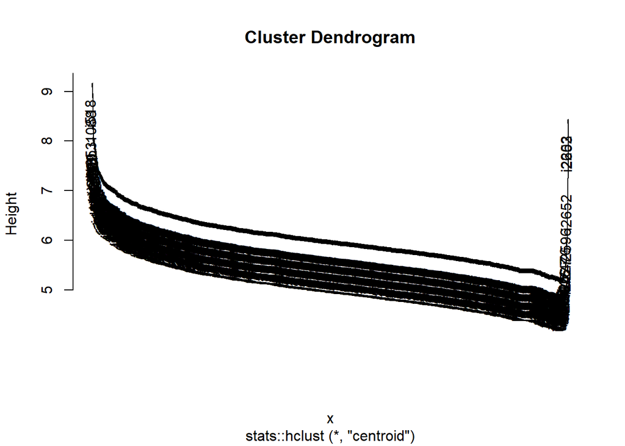

```r
# Display the dendrogram
plot(hc.res_a)
```

```
##    cluster size ave.sil.width
## 1        1 1472          0.02
## 2        2    1          0.00
## 3        3    1          0.00
## 4        4    1          0.00
## 5        5    1          0.00
## 6        6    1          0.00
## 7        7    1          0.00
## 8        8    1          0.00
## 9        9    1          0.00
## 10      10    1          0.00
## 11      11    1          0.00
## 12      12    1          0.00
## 13      13    1          0.00
## 14      14    1          0.00
## 15      15    1          0.00
## 16      16    1          0.00
## 17      17    1          0.00
## 18      18    1          0.00
## 19      19    1          0.00
```

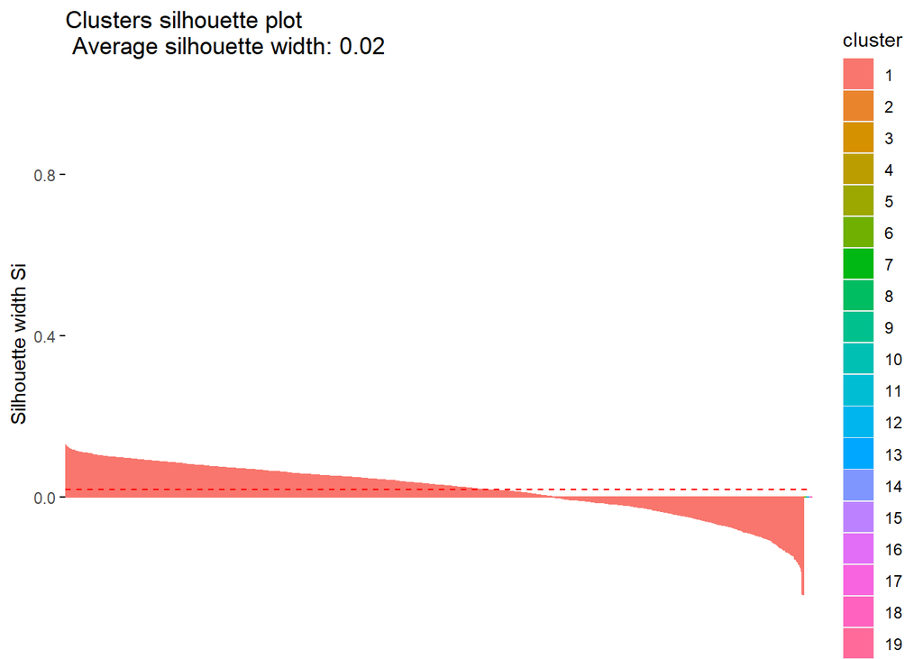

```r
# Visualize Silhouette coefficients
if (input_data_col <= 50) {
  fviz_silhouette(hc.res_a, label = TRUE)
} else {
  fviz_silhouette(hc.res_a, label = FALSE)
}
```

```r
# Silhouette information
silinfo_a <- hc.res_a$silinfo

# The Silhouette coefficient of each sample
sil_a <- hc.res_a$silinfo$widths[, 1:3]
sil_a
```

```
##       cluster neighbor     sil_width
## i316        1        7  0.1286344085
## i1349       1       19  0.1269552470
## i2187       1        5  0.1242392491
## i1524       1        8  0.1235119760
## i1805       1        5  0.1232783866
## i1819       1        8  0.1229575338
## i1430       1        2  0.1212486289
## i619        1       19  0.1212096487
## i1413       1       19  0.1194868376
## i2650       1       14  0.1184701639
## i1481       1        5  0.1179635284
## i2745       1       14  0.1172175845
## i1440       1       14  0.1169758264
## i970        1       17  0.1166698208
## i1749       1       19  0.1166541179
## i1467       1       14  0.1164155884
## i2730       1       11  0.1158633302
## i735        1       14  0.1150370122
## i1244       1       11  0.1141983348
## i2110       1       14  0.1136236136
## i734        1        8  0.1133298940
## i2476       1        5  0.1132802444
## i1438       1       14  0.1130800725
## i1703       1        8  0.1130800384
## i1245       1       14  0.1129722261
## i571        1       14  0.1128766830
## i1545       1        5  0.1115449206
## i2171       1        3  0.1115166119
## i1264       1        8  0.1113972516
## i1488       1        4  0.1113355763
## i2260       1        8  0.1110706259
## i285        1       10  0.1108129607
## i1598       1        8  0.1104681296
## i1465       1       16  0.1102413033
## i2134       1       11  0.1098438541
## i2157       1       19  0.1098392773
## i944        1        5  0.1095287676
## i428        1       14  0.1089256682
## i948        1       19  0.1087510441
```

[output cut: 1436 more lines]

```
## i312        5        1  0.0000000000
## i518        6       18  0.0000000000
## i621        7       18  0.0000000000
## i925        8       17  0.0000000000
## i1088       9       13  0.0000000000
## i1131      10       11  0.0000000000
## i1167      11       15  0.0000000000
## i1295      12       15  0.0000000000
## i1353      13       18  0.0000000000
## i1640      14        1  0.0000000000
## i1798      15       11  0.0000000000
## i1911      16       19  0.0000000000
## i2125      17        8  0.0000000000
## i2159      18       13  0.0000000000
## i2580      19       16  0.0000000000
```

```r
# The average silhouette coefficient of each cluster
silinfo_a$clus.avg.widths
```

```
##  [1] 0.01905165 0.00000000 0.00000000 0.00000000 0.00000000 0.00000000
##  [7] 0.00000000 0.00000000 0.00000000 0.00000000 0.00000000 0.00000000
## [13] 0.00000000 0.00000000 0.00000000 0.00000000 0.00000000 0.00000000
## [19] 0.00000000
```

```r
# The average silhouette coefficient
silinfo_a$avg.width
```

```
## [1] 0.0188215
```

```r
# The size of each cluster
hc.res_a$size
```

```
##  [1] 1472    1    1    1    1    1    1    1    1    1    1    1    1    1    1
## [16]    1    1    1    1
```

```r
# Identify the potential outliers
neg_sil_index_a <- which(sil_a[, 'sil_width'] < SC_max)

# Get the potential outlier sample names
hcOutliers = rownames(sil_a[neg_sil_index_a, , drop = FALSE])
hcOutliers
```

```
##    [1] "i316"  "i1349" "i2187" "i1524" "i1805" "i1819" "i1430" "i619"  "i1413"
##   [10] "i2650" "i1481" "i2745" "i1440" "i970"  "i1749" "i1467" "i2730" "i735"
##   [19] "i1244" "i2110" "i734"  "i2476" "i1438" "i1703" "i1245" "i571"  "i1545"
##   [28] "i2171" "i1264" "i1488" "i2260" "i285"  "i1598" "i1465" "i2134" "i2157"
##   [37] "i944"  "i428"  "i948"  "i2395" "i444"  "i1897" "i2746" "i1035" "i806"
##   [46] "i1258" "i1503" "i2581" "i1320" "i234"  "i2409" "i874"  "i219"  "i1401"
##   [55] "i410"  "i437"  "i1279" "i1926" "i1228" "i2478" "i1386" "i478"  "i2760"
##   [64] "i2761" "i1130" "i1056" "i533"  "i2427" "i1910" "i2475" "i2092" "i919"
##   [73] "i2663" "i2054" "i795"  "i1464" "i2108" "i1309" "i1114" "i1877" "i1237"
##   [82] "i1190" "i1120" "i2233" "i1784" "i2263" "i660"  "i1514" "i1446" "i2460"
##   [91] "i637"  "i1231" "i601"  "i1193" "i1166" "i699"  "i1499" "i854"  "i1454"
##  [100] "i605"  "i477"  "i701"  "i1658" "i587"  "i1614" "i1182" "i1932" "i2294"
##  [109] "i2010" "i908"  "i1772" "i1689" "i1516" "i474"  "i1248" "i2634" "i560"
##  [118] "i965"  "i1930" "i2485" "i566"  "i1371" "i1066" "i382"  "i540"  "i2133"
##  [127] "i2555" "i2714" "i1376" "i1275" "i2077" "i2710" "i1900" "i1862" "i719"
```

[output cut: 151 more lines]

## 4. Robust PCA

Robust PCA is used to detect outliers (Hubert et al 2005). The samples are plotted on a diagnostic plot (diagPlot), aka, a Distance-Distance plot (DD-plot; not to be confused with a plot of PC1 vs. PC2). There are two cutoffs (one horizontal, one vertical) used to classify each sample as an outlier or a non-outlier. Each cutoff corresponds to a 97.5% probability (default setting) that a sample from a normal distribution would not be falsely classified as an outlier. The two cutoffs, robpca_prob and PcaGrid_prob, can be altered at the beginning of the script. If the sample is in the lower-left section of the DD-plot, it is classified as a non-outlier; otherwise, it is classified as an outlier.

### 4.1 Robust Sparse PCA algorithm (robpca)

The sparse robust PCA algorithm (robpca) is based on the ROBPCA algorithm (Hubert et al 2005). rospca has been used to detect outliers in transcriptomics datasets (Selicato et al 2021).

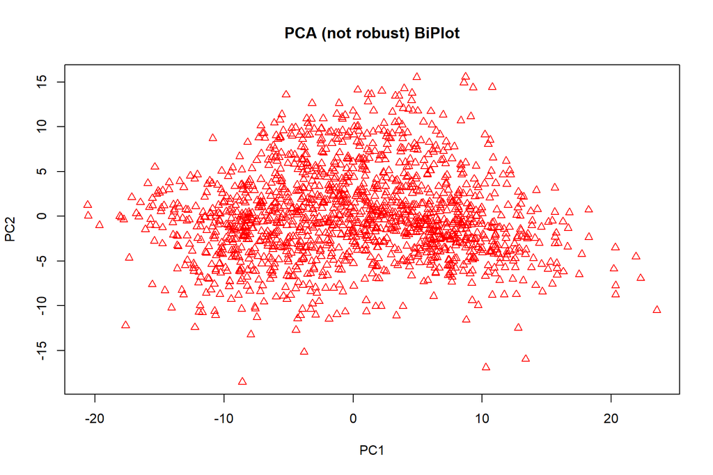

```r
library(rospca)

# Perform a PCA (not robust)
PCA_classic <- prcomp(input_data_nna_t, retx = TRUE, center = TRUE, scale. = TRUE, tol = NULL, rank. = NULL)

# Plot the non-robust PCA results on a PC1-vs-PC2 biplot.  Use text() to include labels.
if (input_data_col <= 50) {
  plot(PCA_classic$x, pch=2, col="red", main = "PCA (not robust) BiPlot")
  text(PCA_classic$x, labels=rownames(PCA_classic$x), cex=0.5, pos=3, col="blue")
} else {
  plot(PCA_classic$x, pch=2, col="red", main = "PCA (not robust) BiPlot")
}
```

```r
# Display table of the non-robust PCA results
PCA_classic$x[,c(1,2)]
```

```
##                 PC1          PC2
## i4      8.030844170   1.77736728
## i5    -15.796163430   0.97866118
## i7     10.465138158  -6.23576371
## i10    -1.840763584  -2.99772655
## i11     6.182202702  -1.02552967
## i20     3.668245901   1.47410110
## i22    -4.714906262  -0.97726495
## i24    11.927912157  -4.28814416
## i25     5.150503839  -1.72819333
## i36     6.078281198  -1.83019408
## i37    -2.281949099   1.60644308
## i39     7.356550869  -6.59543859
## i41   -15.366674247   5.49306751
## i42     4.439658440  -4.92349210
## i43     9.162035921  -0.91682900
## i52     7.956662989  -2.94681510
## i57     6.551385175  -1.78741917
## i58   -12.050091709  -2.46102272
## i59   -11.469439574  -0.05116491
## i68   -15.733079663  -0.99803230
## i70   -13.600043785   1.39140974
## i72    12.553078781  -4.73448095
## i73     5.737890675  -0.27390156
## i74     0.693460323  -3.80314267
## i75     7.185314593  -0.83675404
## i85     8.083815603   0.46092482
## i86     4.585489983   1.22671722
## i87   -19.666042363  -1.02025864
## i88     6.404018690  -3.12270484
## i89     4.401665578  -1.36904829
## i90     7.559613545  -2.54747281
## i100    3.976541836  -1.96385414
## i101    1.900157657   3.04408486
## i103    6.223026897  -3.18430921
## i104    2.597672283   0.17288501
## i105    3.366873491   1.51030170
## i106    6.028434416  -4.96900397
## i116    3.055503740   0.43851777
## i120    3.479899219  -3.81275688
```

[output cut: 1436 more lines]

```
## i2748  -3.212143795   2.46624099
## i2749  -5.943044867  -2.63590336
## i2750  -7.072748266   1.43816384
## i2751   2.408705151   0.31825317
## i2757   3.647042014  -0.23752908
## i2758  -4.118533295  -1.29877959
## i2759   0.051170961   4.35162751
## i2760  -1.113020595   0.15733773
## i2761  -3.207144144  -5.01824198
## i2762  10.905612682  -0.63895789
## i2763  -7.522054685  -0.69285237
## i2764   9.683345426   3.21143997
## i2765  -4.853714409  -8.79739956
## i2766  -8.636872399   3.52272643
## i2767  15.623443485   3.18486497
```

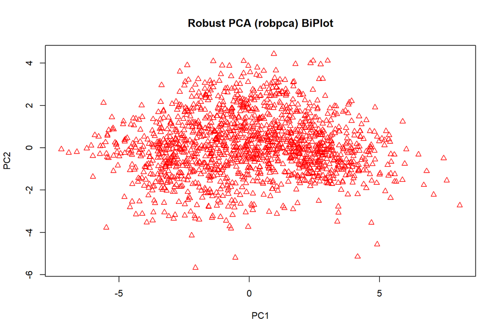

```r
# Perform Robust PCA (robpca)
resR0 <- robpca(input_data_nna_t, k = 0, crit.pca.distances = robpca_prob, ndir = 5000, skew = FALSE)

# Plot the robpca results on a PC1-vs-PC2 biplot.  Use text() to include labels.
if (input_data_col <= 50) {
  plot(resR0$scores, pch=2, col="red", main = "Robust PCA (robpca) BiPlot")
  text(resR0$scores, labels=rownames(resR0$scores), cex=0.5, pos=3, col="blue")
  } else {
  plot(resR0$scores, pch=2, col="red", main = "Robust PCA (robpca) BiPlot")
  }
```

```r
# Display table of the robpca results
resR0$scores[,c(1,2)]
```

```
##               PC1           PC2
## i4     2.54841434  0.6607918545
## i5    -5.52059053  0.2606557851
## i7     3.81393069 -1.2722045005
## i10    0.04752641 -0.9596665045
## i11    1.91318711 -0.0591564738
## i20    1.43849566  0.2749616260
## i22   -1.45610698 -0.2842471090
## i24    4.13829378 -0.8250369265
## i25    1.69752303  0.1033971230
## i36    2.13727974 -0.6972478870
## i37   -0.89594321  0.0655548535
## i39    3.03523285 -1.6927703372
## i41   -5.60094465  2.1274513882
## i42    1.91564388 -1.5793054531
## i43    3.05582151  0.3152009078
## i52    2.72519066 -0.4884115774
## i57    2.49378167 -0.2651935672
## i58   -3.97591673 -0.9167510902
## i59   -4.07473230  0.0463116284
## i68   -5.46348133 -0.4499813506
## i70   -4.47784414  0.2037376185
## i72    4.48655385 -1.0758098896
## i73    1.74612864  0.1050342759
## i74    0.73020495 -0.7479770112
## i75    2.29619192  0.1008903214
## i85    2.80821937  0.2334283444
## i86    1.60297971  0.3242879833
## i87   -6.62470821 -0.2008120791
## i88    2.11978092 -0.7118137400
## i89    1.65427959 -0.2081448633
## i90    2.55306027 -0.4731075758
## i100   1.54562747 -0.5134495091
## i101   0.44195368  0.8421868288
## i103   2.50637679 -0.7205353118
## i104   0.95500410  0.4135708321
## i105   0.93318849  0.8129944074
## i106   2.27325078 -1.2508290814
## i116   1.08147911  0.3744892804
## i120   1.38678010 -1.1664641111
```

[output cut: 1436 more lines]

```
## i2748 -1.17332849  0.9955274952
## i2749 -2.42002095 -0.6259296343
## i2750 -2.61807279  0.6481064675
## i2751  0.61262314  0.6522421429
## i2757  1.00512584  0.0816803964
## i2758 -1.51124508 -0.1035325931
## i2759 -0.10496765  0.2738943258
## i2760 -0.11708343 -0.6626543913
## i2761 -0.65400707 -1.6510515851
## i2762  3.89147140 -0.0075145706
## i2763 -2.43470212  0.1114963606
## i2764  3.00469288  1.5996941034
## i2765 -1.19789369 -2.4952980999
## i2766 -3.10055339  1.4301150124
## i2767  4.82468448  1.9115435749
```

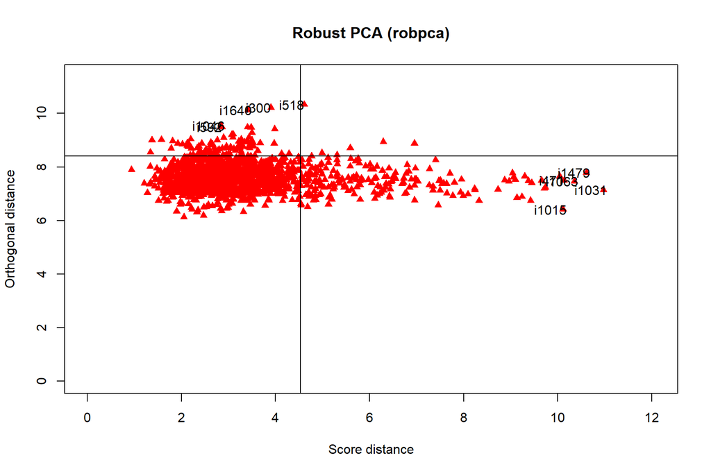

```r
# Diagnositc plot (DD-plot or outlier map)
diagPlot(resR0, title = "Robust PCA (robpca)", pch = 17, col="red", labelOut = TRUE, id = 5)
```

```r
# Display the robpca results (outliers are 'FALSE')
resR0_flag <- as.data.frame(resR0$flag.all)
resR0_flag
```

```
##       resR0$flag.all
## i4              TRUE
## i5              TRUE
## i7              TRUE
## i10             TRUE
## i11             TRUE
## i20             TRUE
## i22             TRUE
## i24             TRUE
## i25             TRUE
## i36             TRUE
## i37             TRUE
## i39             TRUE
## i41             TRUE
## i42             TRUE
## i43             TRUE
## i52             TRUE
## i57             TRUE
## i58             TRUE
## i59             TRUE
## i68             TRUE
## i70             TRUE
## i72             TRUE
## i73             TRUE
## i74             TRUE
## i75             TRUE
## i85             TRUE
## i86             TRUE
## i87            FALSE
## i88             TRUE
## i89             TRUE
## i90             TRUE
## i100            TRUE
## i101            TRUE
## i103            TRUE
## i104            TRUE
## i105            TRUE
## i106            TRUE
## i116            TRUE
## i120            TRUE
```

[output cut: 1436 more lines]

```
## i2748           TRUE
## i2749           TRUE
## i2750           TRUE
## i2751           TRUE
## i2757           TRUE
## i2758           TRUE
## i2759          FALSE
## i2760          FALSE
## i2761           TRUE
## i2762           TRUE
## i2763           TRUE
## i2764           TRUE
## i2765           TRUE
## i2766          FALSE
## i2767          FALSE
```

```r
resR0_flag$sample <- row.names(resR0_flag)
colnames(resR0_flag) <- c('regular', 'sample')
resR0_flag$regular <- as.numeric(resR0_flag$regular)

# Display the outlier sample names
rosOutliers = resR0_flag[resR0_flag$regular == 0,]$sample
rosOutliers
```

```
##   [1] "i87"   "i149"  "i151"  "i156"  "i181"  "i183"  "i199"  "i200"  "i213"
##  [10] "i215"  "i231"  "i232"  "i245"  "i247"  "i252"  "i261"  "i263"  "i265"
##  [19] "i272"  "i279"  "i281"  "i282"  "i293"  "i295"  "i300"  "i309"  "i311"
##  [28] "i312"  "i319"  "i325"  "i327"  "i341"  "i343"  "i357"  "i359"  "i366"
##  [37] "i373"  "i375"  "i389"  "i391"  "i406"  "i407"  "i421"  "i423"  "i439"
##  [46] "i441"  "i448"  "i453"  "i455"  "i456"  "i469"  "i470"  "i471"  "i472"
##  [55] "i474"  "i485"  "i487"  "i488"  "i495"  "i501"  "i503"  "i504"  "i517"
##  [64] "i518"  "i519"  "i520"  "i533"  "i535"  "i536"  "i544"  "i551"  "i565"
##  [73] "i567"  "i581"  "i583"  "i592"  "i597"  "i613"  "i615"  "i621"  "i624"
##  [82] "i631"  "i640"  "i647"  "i660"  "i664"  "i695"  "i709"  "i719"  "i720"
##  [91] "i733"  "i839"  "i847"  "i853"  "i863"  "i885"  "i887"  "i893"  "i896"
## [100] "i901"  "i911"  "i919"  "i925"  "i933"  "i935"  "i938"  "i943"  "i999"
## [109] "i1000" "i1002" "i1006" "i1007" "i1015" "i1016" "i1029" "i1031" "i1032"
## [118] "i1038" "i1039" "i1040" "i1045" "i1046" "i1047" "i1048" "i1052" "i1063"
## [127] "i1064" "i1068" "i1071" "i1077" "i1079" "i1088" "i1095" "i1116" "i1125"
```

[output cut: 19 more lines]

### 4.2 Robust PCA based on Projection Pursuit (PP) using GRID (PcaGrid)

PcaGrid computes an approximation of the PP-estimators for a robust PCA using the GRID algorithm to detect outlier samples. It was compared with PcaHubert, and had better sensitivity and specificity for simulated and real transcriptomics data (Chen et al 2020).

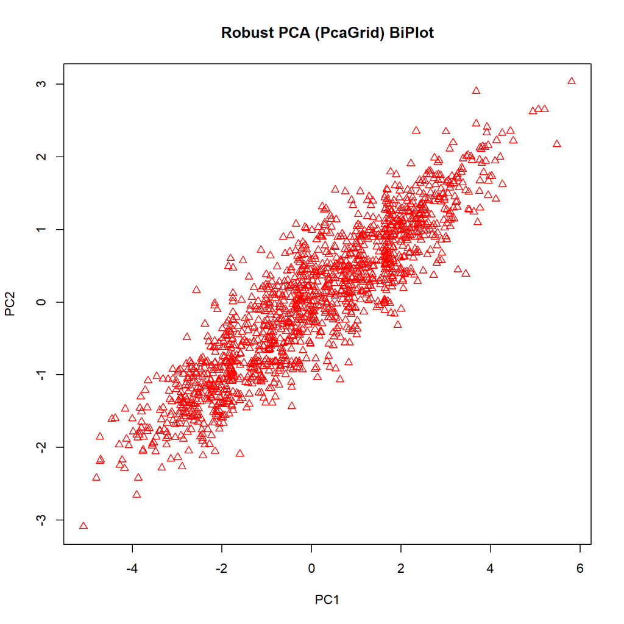

```r
library(rrcov)

# Perform a Robust PCA (PcaGrid)
pc <- PcaGrid(input_data_nna_t, crit.pca.distances = PcaGrid_prob)

# Plot the PcaGrid results on a PC1-vs-PC2 biplot.  Use text() to include labels.
if (input_data_col <= 50) {
  plot(pc$scores, pch=2, col="red", main = "Robust PCA (PcaGrid) BiPlot")
  text(pc$scores, labels=rownames(pc$scores), cex=0.5, pos=3, col="blue")
  } else {
  plot(pc$scores, pch=2, col="red", main = "Robust PCA (PcaGrid) BiPlot")
  }
```

```r
# Display table of the PcaGrid results
pc$scores[,c(1,2)]
```

```
##                PC1           PC2
## i4     1.792979894  0.8963358964
## i5    -3.913678643 -1.8251104574
## i7     2.478723007  1.6754101450
## i10    0.485496019 -0.4152356380
## i11    1.366980481  0.8971879950
## i20    1.526237626  0.2854866408
## i22   -0.994203127 -0.2427839483
## i24    2.846900985  1.4484814163
## i25    1.062932346  0.5815773388
## i36    1.165602192  0.8963565298
## i37   -0.686710200 -0.2396132796
## i39    2.489966181  1.1890898803
## i41   -3.909506588 -2.6548038572
## i42    1.536818606  0.8962401632
## i43    2.253264656  1.4357332122
## i52    2.037505355  0.7726447495
## i57    2.014033505  1.0425168758
## i58   -2.918045782 -1.8360840048
## i59   -3.103818497 -0.9217021173
## i68   -3.800903390 -1.6467407720
## i70   -2.847804361 -1.5715620392
## i72    2.905456487  1.6826673805
## i73    1.203097363  0.5475810209
## i74    0.563237407 -0.0234887638
## i75    1.716657475  0.6656791159
## i85    1.690281514  1.2613982501
## i86    1.630102572  0.5088645647
## i87   -4.811209512 -2.4169194355
## i88    1.630165694  0.1919400179
## i89    1.261070144  0.8673698582
## i90    1.745158593  1.2830747403
## i100   1.318569470  0.0441057144
## i101   0.497799161  0.4586819207
## i103   1.676096500  1.5536954987
## i104   0.678967691  0.1629202766
## i105   0.684954349  0.3574604743
## i106   1.702546141  0.6119490843
## i116   0.930482352  0.4598705358
## i120   1.125766238  0.8962937167
```

[output cut: 1436 more lines]

```
## i2748 -0.820105015 -0.8148427725
## i2749 -1.790411747 -1.0016595415
## i2750 -1.959359400 -1.2140850704
## i2751  0.370237875 -0.2137362305
## i2757  0.435635251  1.1401936331
## i2758 -1.405746641 -0.2056381749
## i2759  0.010261296  0.0088055400
## i2760  0.030515234  0.0949447703
## i2761 -0.269749759  0.2297816366
## i2762  3.020962927  1.2686451830
## i2763 -1.878926090 -0.5905673581
## i2764  2.443997516  0.8533465927
## i2765 -1.045376727 -0.1274218378
## i2766 -2.158538321 -2.0531496054
## i2767  3.709246816  1.0956742315
```

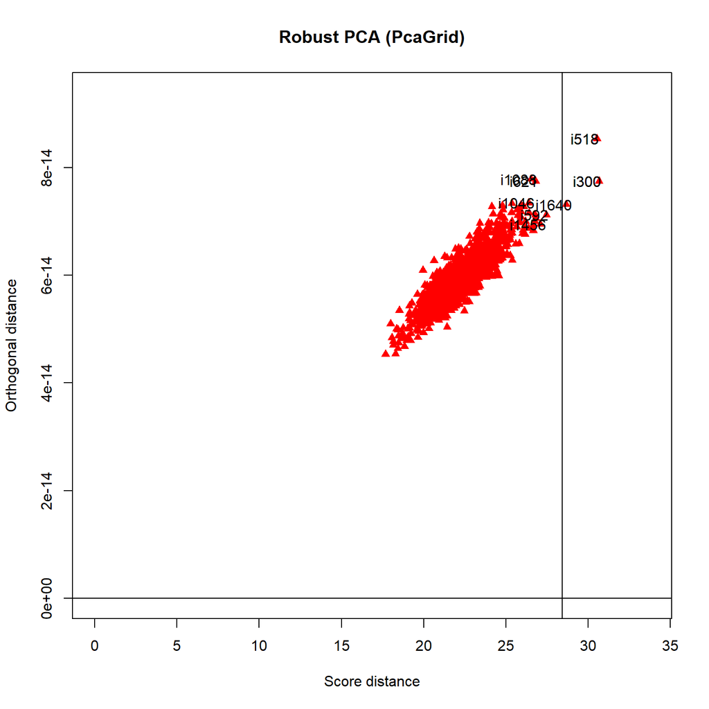

```r
# Diagnositc plot (DD-plot or outlier map)
diagPlot(pc, title = "Robust PCA (PcaGrid)", pch = 17, col="red", labelOut = TRUE, id = 5)
```

```r
# Display the results (outliers = FALSE)
pc_flag <- as.data.frame(pc$flag)
pc_flag
```

```
##       pc$flag
## i4       TRUE
## i5       TRUE
## i7       TRUE
## i10      TRUE
## i11      TRUE
## i20      TRUE
## i22      TRUE
## i24      TRUE
## i25      TRUE
## i36      TRUE
## i37      TRUE
## i39      TRUE
## i41      TRUE
## i42      TRUE
## i43      TRUE
## i52      TRUE
## i57      TRUE
## i58      TRUE
## i59      TRUE
## i68      TRUE
## i70      TRUE
## i72      TRUE
## i73      TRUE
## i74      TRUE
## i75      TRUE
## i85      TRUE
## i86      TRUE
## i87      TRUE
## i88      TRUE
## i89      TRUE
## i90      TRUE
## i100     TRUE
## i101     TRUE
## i103     TRUE
## i104     TRUE
## i105     TRUE
## i106     TRUE
## i116     TRUE
## i120     TRUE
```

[output cut: 1436 more lines]

```
## i2748    TRUE
## i2749    TRUE
## i2750    TRUE
## i2751    TRUE
## i2757    TRUE
## i2758    TRUE
## i2759    TRUE
## i2760    TRUE
## i2761    TRUE
## i2762    TRUE
## i2763    TRUE
## i2764    TRUE
## i2765    TRUE
## i2766    TRUE
## i2767    TRUE
```

```r
pc_flag$sample <- row.names(pc_flag)
colnames(pc_flag) <- c('regular', 'sample')
pc_flag$regular <- as.numeric(pc_flag$regular)

# Display the outlier sample names
pcOutliers = pc_flag[pc_flag$regular == 0,]$sample
pcOutliers
```

```
## [1] "i300"  "i518"  "i1640"
```

## 5. Summary of the Results and Identification of Outlier(s)

In this analysis, three different methods were used to examine the samples. They complement each other in the identification potential outlier(s). First, the density plot (made using “plotDensities”) was used to visualize how similar the expression patterns were across the samples. Second, hierarchical clustering was used to examine how close the samples are to each other; closely related samples formed a tight cluster. The Cophenetic Correlation Coefficient (CCC) was used to evaluate if the dendrogram is a good representation of the similarity among the samples. The Silhouette coefficient (SC) was used to examine how strongly each sample belonged to its cluster. Finally, robust PCA analyses were performed using two different algorithms, robpca and PcaGrid. These were used to identify outlier(s) that surpassed a probability threshold. The PcaGrid test was described by Chen et al 2020, and the CCC, SC, and robpca tests were described by Selicato et al 2021.

The robust PCA analyses use statistical testing to robustly identify the outlier(s). The density plot and hierarchical clustering provide additional visual and descriptive information. Ideally, they will confirm the rPCA results by showing that the outlier(s) are distant from the other samples.

### 5.1 Outlier(s) Identified by Robust PCA analyses

```r
# A robpca cutoff of 0.975 is recommended (Selicato et al 2021).
# At the start of the script, the robpca cutoff was set to:
robpca_prob
```

```
## [1] 0.975
```

```r
# The samples that are outside this cutoff are potential outliers, and the other samples are not.
# The samples that are outside this cutoff:
rosOutliers
```

```
##   [1] "i87"   "i149"  "i151"  "i156"  "i181"  "i183"  "i199"  "i200"  "i213"
##  [10] "i215"  "i231"  "i232"  "i245"  "i247"  "i252"  "i261"  "i263"  "i265"
##  [19] "i272"  "i279"  "i281"  "i282"  "i293"  "i295"  "i300"  "i309"  "i311"
##  [28] "i312"  "i319"  "i325"  "i327"  "i341"  "i343"  "i357"  "i359"  "i366"
##  [37] "i373"  "i375"  "i389"  "i391"  "i406"  "i407"  "i421"  "i423"  "i439"
##  [46] "i441"  "i448"  "i453"  "i455"  "i456"  "i469"  "i470"  "i471"  "i472"
##  [55] "i474"  "i485"  "i487"  "i488"  "i495"  "i501"  "i503"  "i504"  "i517"
##  [64] "i518"  "i519"  "i520"  "i533"  "i535"  "i536"  "i544"  "i551"  "i565"
##  [73] "i567"  "i581"  "i583"  "i592"  "i597"  "i613"  "i615"  "i621"  "i624"
##  [82] "i631"  "i640"  "i647"  "i660"  "i664"  "i695"  "i709"  "i719"  "i720"
##  [91] "i733"  "i839"  "i847"  "i853"  "i863"  "i885"  "i887"  "i893"  "i896"
## [100] "i901"  "i911"  "i919"  "i925"  "i933"  "i935"  "i938"  "i943"  "i999"
## [109] "i1000" "i1002" "i1006" "i1007" "i1015" "i1016" "i1029" "i1031" "i1032"
## [118] "i1038" "i1039" "i1040" "i1045" "i1046" "i1047" "i1048" "i1052" "i1063"
## [127] "i1064" "i1068" "i1071" "i1077" "i1079" "i1088" "i1095" "i1116" "i1125"
```

[output cut: 19 more lines]

```r
# A PcaGrid cutoff of 0.975 is recommended (Chen et al 2020).
# At the start of the script, the PcaGrid cutoff was set to:
PcaGrid_prob
```

```
## [1] 0.975
```

```r
# The samples that are outside this cutoff are potential outliers, and the other samples are not.
# The samples that are outside this cutoff:
pcOutliers
```

```
## [1] "i300"  "i518"  "i1640"
```

```r
# The samples that satisfied both robust PCA (robpca and PcaGrid) criteria for an outlier:
intersect(pcOutliers, rosOutliers)
```

```
## [1] "i300"  "i518"  "i1640"
```

### 5.2 Outlier(s) Identified by Hiearchical Clustering

```r
# A CCC cutoff of 0.8 is recommended (Selicato et al 2021).
# At the start of the script, the CCC cutoff was set to:
CCC_min
```

```
## [1] 0.8
```

```r
# The CCC was calculated:
CCC_df_ranked_top$CCC
```

```
## [1] 0.6979108
```

```r
# Did the input data pass the CCC test? (TRUE = yes, FALSE = no)
# If TRUE, then the HCA clustering was informative, and subsequent outlier detection can be informative.
# If FALSE, then the HCA clustering wasn't informative, and subsequent outlier detection won't be informative.
CCC_df_ranked_top$CCC >= CCC_min
```

```
## [1] FALSE
```

```r
# An SC cutoff of 0.25 is recommended (Selicato et al 2021).
# At the start of the script, the SC cutoff was set to:
SC_max
```

```
## [1] 0.25
```

```r
# The samples that have an SC value lower than the SC cutoff
# are potential outliers, and the other samples are not.
# The samples that have an SC value lower than the SC cutoff:
hcOutliers
```

```
##    [1] "i316"  "i1349" "i2187" "i1524" "i1805" "i1819" "i1430" "i619"  "i1413"
##   [10] "i2650" "i1481" "i2745" "i1440" "i970"  "i1749" "i1467" "i2730" "i735"
##   [19] "i1244" "i2110" "i734"  "i2476" "i1438" "i1703" "i1245" "i571"  "i1545"
##   [28] "i2171" "i1264" "i1488" "i2260" "i285"  "i1598" "i1465" "i2134" "i2157"
##   [37] "i944"  "i428"  "i948"  "i2395" "i444"  "i1897" "i2746" "i1035" "i806"
##   [46] "i1258" "i1503" "i2581" "i1320" "i234"  "i2409" "i874"  "i219"  "i1401"
##   [55] "i410"  "i437"  "i1279" "i1926" "i1228" "i2478" "i1386" "i478"  "i2760"
##   [64] "i2761" "i1130" "i1056" "i533"  "i2427" "i1910" "i2475" "i2092" "i919"
##   [73] "i2663" "i2054" "i795"  "i1464" "i2108" "i1309" "i1114" "i1877" "i1237"
##   [82] "i1190" "i1120" "i2233" "i1784" "i2263" "i660"  "i1514" "i1446" "i2460"
##   [91] "i637"  "i1231" "i601"  "i1193" "i1166" "i699"  "i1499" "i854"  "i1454"
##  [100] "i605"  "i477"  "i701"  "i1658" "i587"  "i1614" "i1182" "i1932" "i2294"
##  [109] "i2010" "i908"  "i1772" "i1689" "i1516" "i474"  "i1248" "i2634" "i560"
##  [118] "i965"  "i1930" "i2485" "i566"  "i1371" "i1066" "i382"  "i540"  "i2133"
##  [127] "i2555" "i2714" "i1376" "i1275" "i2077" "i2710" "i1900" "i1862" "i719"
```

[output cut: 151 more lines]

```r
# The samples that satisfied the CCC, SC, and robpca criteria for an outlier:
if (CCC_df_ranked_top$CCC >= CCC_min) {
  intersect(hcOutliers, rosOutliers)
}
```

### 5.3 Outlier(s) Identified by Both HCA and Robust PCA

```r
# The samples that satisfied all four criteria (CCC, SC, robpca, PcaGrid) for an outlier:
if (CCC_df_ranked_top$CCC >= CCC_min) {
  intersect(intersect(hcOutliers, rosOutliers), pcOutliers)
}
```

## 6. References

Boris Iglewicz and David Hoaglin 1993 “Volume 16: How to Detect and Handle Outliers”, The ASQC Basic References in Quality Control: Statistical Techniques, Edward F. Mykytka, Ph.D., Editor.

Charrad et al 2014 NbClust: An R Package for Determining the Relevant Number of Clusters in a Data Set. J Statistical Software 61:1-36.

Chen et al 2020 Robust principal component analysis for accurate outlier sample detection in RNA-Seq data. BMC Bioinformatics. 21:269.

Hubert et al 2005 ROBPCA: a new approach to robust prinicipal component analysis. Technometrics 47(1):64-79.

Selicato et al 2021 A New Ensemble Method for Detecting Anomalies in Gene Expression Matrices. Mathematics 9:882.

Spiess and Neumeyer 2010 An evaluation of R2 as an inadequate measure for nonlinear models in pharmacological and biochemical research: a Monte Carlo approach. BMC Pharmacol 10:6.